# 1.1) Introduction and overview

**Goal:** To know more about what make the customer churn and predicting if he will churn or not.

**Data set:** The data was downloaded from IBM Sample Data Sets for customer retention programs.

The data set includes information about:

- Customers who left within the last month – the column is called Churn
- Services that each customer has signed up for – phone, multiple lines, internet, online security, online backup, device protection, tech support, and streaming TV and movies
- Customer account information – how long they’ve been a customer, contract, payment method, paperless billing, monthly charges, and total charges
- Demographic info about customers – gender, age range, and if they have partners and dependents

**You can download it from here:** https://www.kaggle.com/blastchar/telco-customer-churn/download

# 1.2) excutive summary

## In this project you will fined :

1. Exploratory data analysis for categorical variables
2. Exploratory data analysis for numerical variables
3. Data cleaning and handling missing values
4. Base Model
5. discussion about how to evaluate the models
6. Logistic regression
7. Decission Tree
8. Random forests
9. Feature engineering
10. Feature selection
11. Stack Model
12. Final Results
13. Conclusion

# 2) Methods and analysis

## 2.1) Data cleaning and Exploratory data analysis

```r
# loading the libraries
library(tidyverse) # metapackage of all tidyverse packages

library(DataExplorer) # to make intro_plot()
library(gridExtra) # to make grid.arrange()

library(caret)

library(randomForest)

library(rpart)
library(rpart.plot)

#loading the data
mydata = read_csv("../input/telco-customer-churn/WA_Fn-UseC_-Telco-Customer-Churn.csv") #Reading the Data

attr(mydata, 'spec') <- NULL # just to remove a warning about specifications
```

```r
str(mydata)
```

```
tibble [7,043 × 21] (S3: spec_tbl_df/tbl_df/tbl/data.frame)
 $ customerID      : chr [1:7043] "7590-VHVEG" "5575-GNVDE" "3668-QPYBK" "7795-CFOCW" ...
 $ gender          : chr [1:7043] "Female" "Male" "Male" "Male" ...
 $ SeniorCitizen   : num [1:7043] 0 0 0 0 0 0 0 0 0 0 ...
 $ Partner         : chr [1:7043] "Yes" "No" "No" "No" ...
 $ Dependents      : chr [1:7043] "No" "No" "No" "No" ...
 $ tenure          : num [1:7043] 1 34 2 45 2 8 22 10 28 62 ...
 $ PhoneService    : chr [1:7043] "No" "Yes" "Yes" "No" ...
 $ MultipleLines   : chr [1:7043] "No phone service" "No" "No" "No phone service" ...
 $ InternetService : chr [1:7043] "DSL" "DSL" "DSL" "DSL" ...
 $ OnlineSecurity  : chr [1:7043] "No" "Yes" "Yes" "Yes" ...
 $ OnlineBackup    : chr [1:7043] "Yes" "No" "Yes" "No" ...
 $ DeviceProtection: chr [1:7043] "No" "Yes" "No" "Yes" ...
 $ TechSupport     : chr [1:7043] "No" "No" "No" "Yes" ...
 $ StreamingTV     : chr [1:7043] "No" "No" "No" "No" ...
 $ StreamingMovies : chr [1:7043] "No" "No" "No" "No" ...
 $ Contract        : chr [1:7043] "Month-to-month" "One year" "Month-to-month" "One year" ...
 $ PaperlessBilling: chr [1:7043] "Yes" "No" "Yes" "No" ...
 $ PaymentMethod   : chr [1:7043] "Electronic check" "Mailed check" "Mailed check" "Bank transfer (automatic)" ...
 $ MonthlyCharges  : num [1:7043] 29.9 57 53.9 42.3 70.7 ...
 $ TotalCharges    : num [1:7043] 29.9 1889.5 108.2 1840.8 151.7 ...
 $ Churn           : chr [1:7043] "No" "No" "Yes" "No" ...
```

so our data set consists of 21 features and 7,043 observations, it's a relatively small dataset which will enable me to do cross validarion, use ensabmle models and so on witout waiting for ever.

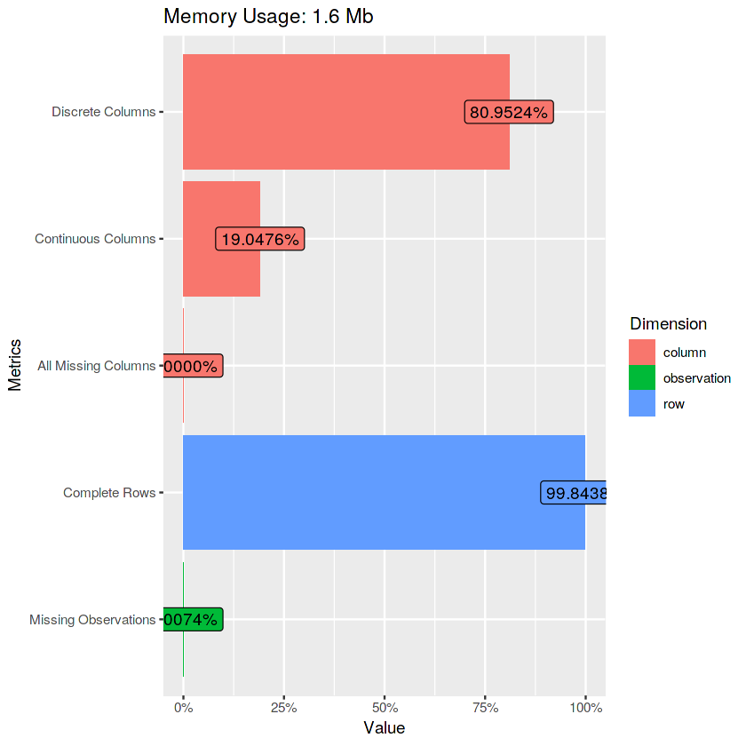

```r
plot_intro(mydata) # let's take an overview on some ascpects about the data
```

So most of our data is discrete, there no a lot of missing values but we need to deal with them by removing or imputing and no columns missing completley.

**Let's see the distrinution of our target variable**

```r
head(as.integer(mydata$Churn == 'Yes')) # this how i can convert it into numerical
```

1. 0

2. 0

3. 1

4. 0

5. 1

6. 1

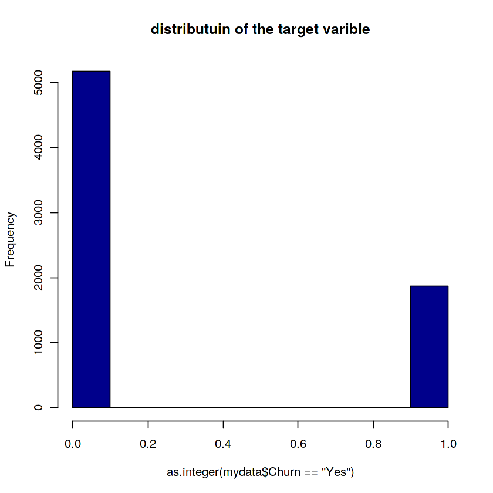

```r
hist(as.integer(mydata$Churn == 'Yes') , col = 'darkblue' , main = 'distributuin of the target varible')
```

We can see that the target feature is inbalanced as much more values are 0 so we may need to check if the model will be baised toward 0 or not

```r
table(mydata$Churn)/nrow(mydata) # seeing the fraction of the zeros and ones in the data
```

```
       No       Yes
0.7346301 0.2653699
```

**customerID**

```r
n_distinct(mydata$customerID)
```

7043

It's just an identifier for customers, it has no repetitions and there is no correlation with the target variable at all so i will remove it in before modelling

### Factor variables

**gender**

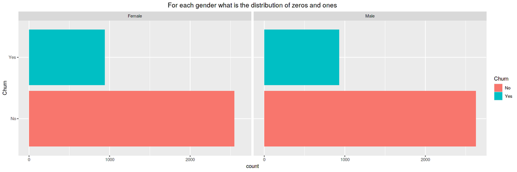

```r
options(repr.plot.width = 15, repr.plot.height = 5)
ggplot(mydata , aes( y = Churn ,fill = Churn)) + geom_bar() + facet_wrap(. ~ gender)+
  ggtitle("For each gender what is the distribution of zeros and ones") +
  theme(plot.title = element_text(hjust = 0.5))
```

We can see clearly that there is no specific gender correlated with Churned or not churned both genders has the same distribution for both 0 and 1

**SeniorCitizen** `An older person, usually over the age of 60 or 65, esp. one who is no longer employed`

```
           No       Yes
  0 0.7639383 0.2360617
  1 0.5831874 0.4168126
```

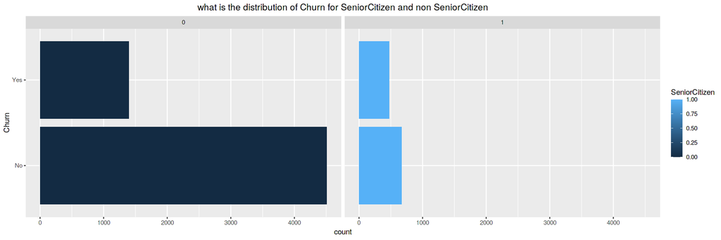

```r
prop.table(table(mydata$SeniorCitizen,mydata$Churn),1) # i want to get the ratio of Churn and in all levels

options(repr.plot.width = 15, repr.plot.height = 5)

ggplot(mydata , aes( y = Churn ,fill = SeniorCitizen)) + geom_bar() + facet_wrap(. ~ SeniorCitizen )+
  ggtitle("what is the distribution of Churn for SeniorCitizen and non SeniorCitizen") +
  theme(plot.title = element_text(hjust = 0.5))
```

The fraction of churned out of all SeniorCitizen is much bigger that the fraction of churned out of all non SeniorCitizen so being SeniorCitizen is indeed an important factor of churning

**Partner** `Whether the customer has a partner or not (Yes, No)`

```
       No       Yes
0.5169672 0.4830328
```

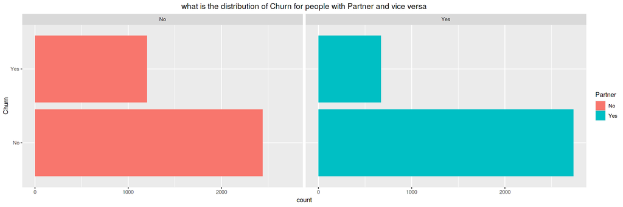

```r
table(mydata$Partner)/nrow(mydata) # distribution of people who have partner and who not
options(repr.plot.width = 15, repr.plot.height = 5)
ggplot(mydata , aes( y = Churn ,fill = Partner)) + geom_bar() + facet_wrap(. ~ Partner )+
  ggtitle("what is the distribution of Churn for people with Partner and vice versa") +
  theme(plot.title = element_text(hjust = 0.5))
```

So half the pople have Partner and they have less probability of Churning than people who don't have as we can see the fraction of churned in Partner group is less than no Partner group

**Dependents**

```
             No       Yes
  No  0.6872086 0.3127914
  Yes 0.8454976 0.1545024
```

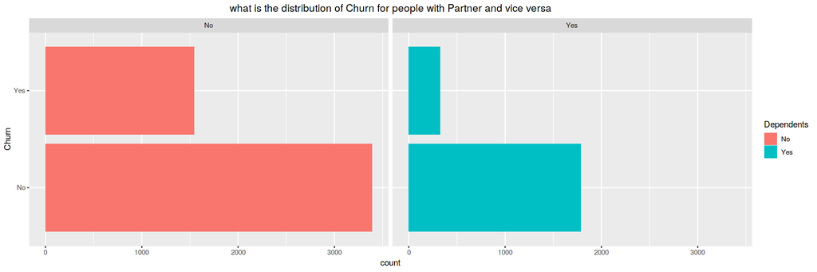

```r
prop.table(table(mydata$Dependents,mydata$Churn),1)# i want to get the ratio of Churn and in all levels
options(repr.plot.width = 15, repr.plot.height = 5)
ggplot(mydata , aes( y = Churn ,fill = Dependents)) + geom_bar() + facet_wrap(. ~ Dependents )+
  ggtitle("what is the distribution of Churn for people with Partner and vice versa") +
  theme(plot.title = element_text(hjust = 0.5))
```

So the ratio of churned people who don't have Dependents is 31% wehre in the people who have dependent is 15% only which is half the ratio which means that not having dependent increse the probability of churn

**This brought me to think that interaction variables will be very important here like for example a person who is has no Partner,a SeniorCitizen, has no Dependents, ect ... is likely to Churn than others so introducing this kind of interactions to the model in an implicit way would help in better accuracy and model explainability.**

**InternetService** `Weather DSL, Fiber optic or No internet service at all`

**OnlineSecurity** `Yes, No, No internet service`

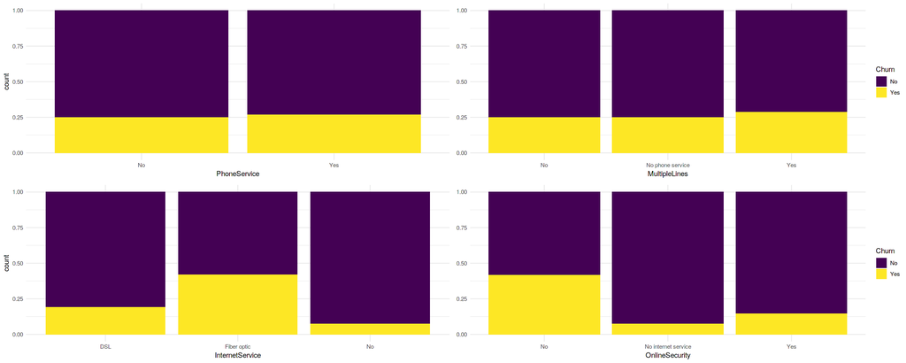

```r
options(repr.plot.width = 20, repr.plot.height = 8)

grid.arrange(
ggplot(mydata, aes(x=PhoneService,fill=Churn))+
    geom_bar(position = 'fill', show.legend = FALSE) +
    scale_fill_ordinal() +
    theme_minimal(),

    ggplot(mydata, aes(x=MultipleLines,fill=Churn))+
    geom_bar(position = 'fill')+
    labs(y = NULL) + scale_fill_ordinal() +
    theme_minimal(),

    ggplot(mydata, aes(x=InternetService,fill=Churn))+
    geom_bar(position = 'fill', show.legend = FALSE) +
    scale_fill_ordinal() +
    theme_minimal(),

    ggplot(mydata, aes(x=OnlineSecurity,fill=Churn))+
    geom_bar(position = 'fill')+labs(y = NULL) +
    scale_fill_ordinal() +
    theme_minimal(),

    nrow = 2
)
```

**OnlineBackup** **DeviceProtection** **TechSupport** **StreamingTV**

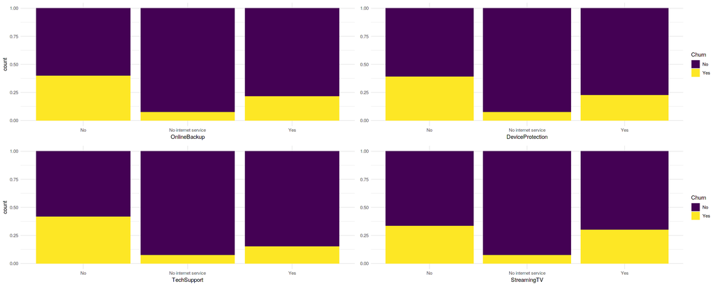

```r
options(repr.plot.width = 20, repr.plot.height = 8)
grid.arrange(
ggplot(mydata, aes(x=OnlineBackup,fill=Churn))+
    geom_bar(position = 'fill', show.legend = FALSE) +
    scale_fill_ordinal() +
    theme_minimal(),

    ggplot(mydata, aes(x=DeviceProtection,fill=Churn))+
    geom_bar(position = 'fill')+
    labs(y = NULL) +
    scale_fill_ordinal() +
    theme_minimal(),

    ggplot(mydata, aes(x=TechSupport,fill=Churn))+
    geom_bar(position = 'fill', show.legend = FALSE) +
    scale_fill_ordinal() +
    theme_minimal(),

    ggplot(mydata, aes(x=StreamingTV,fill=Churn))+ geom_bar(position = 'fill')+
    labs(y = NULL) +
    scale_fill_ordinal() +
    theme_minimal(),
    nrow = 2
    )
```

The customers with`No` class has higher probability to churn than the others which interesting that these customers may thare some thing that makes them more likely to leave, so it may worth some research !

**StreamingMovies**

**Contract** `The contract term of the customer (Month-to-month, One year, Two year)`

**PaperlessBilling**

**PaymentMethod** `The customer’s payment method (Electronic check, Mailed check, Bank transfer (automatic), Credit card (automatic))`

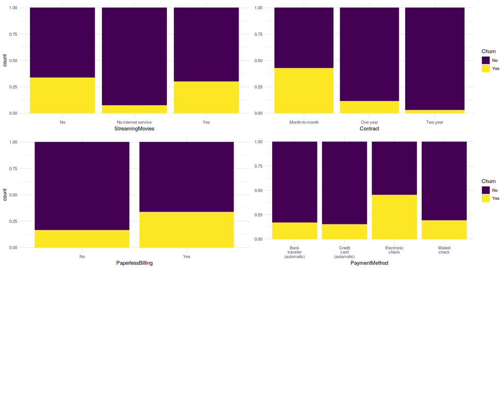

```r
options(repr.plot.width = 15, repr.plot.height = 12)

grid.arrange(
    ggplot(mydata, aes(x=StreamingMovies,fill=Churn))+
    geom_bar(position = 'fill', show.legend = FALSE) +
    scale_fill_ordinal() +
    theme_minimal(),

    ggplot(mydata, aes(x=Contract,fill=Churn))+
    geom_bar(position = 'fill')+labs(y = NULL) +
    scale_fill_ordinal() +
    theme_minimal(),

    ggplot(mydata, aes(x=PaperlessBilling,fill=Churn))+
    geom_bar(position = 'fill', show.legend = FALSE) +
    scale_fill_ordinal() +
    theme_minimal(),

    ggplot(mydata, aes(x=PaymentMethod,fill=Churn))+
    geom_bar(position = 'fill')+
    labs(y = NULL) +
    scale_fill_ordinal() + theme_minimal()+
    scale_x_discrete(labels = function(x) str_wrap(x, width = 10)),

                     nrow=3)
```

It's predictible that people with month to month contract are more likely to churn so we have to give them more care and offers

### Continues variabels

First of all we need to handle the missing values

```r
colnames(mydata)[colSums(is.na(mydata)) > 0] # getting the columns that have missing values
```

'TotalCharges'

```r
mydata2 = mydata %>% select(c(tenure,MonthlyCharges,TotalCharges)) %>% mutate(tenure_TotalCharges = tenure * MonthlyCharges , difference = tenure_TotalCharges -TotalCharges  )
head(mydata2)
summary(mydata2$difference)
sd(na.omit(mydata2$difference))
```

A tibble: 6 × 5

| tenure <dbl> | MonthlyCharges <dbl> | TotalCharges <dbl> | tenure_TotalCharges <dbl> | difference <dbl> |
| --- | --- | --- | --- | --- |
| 1 | 29.85 | 29.85 | 29.85 | 0.00 |
| 34 | 56.95 | 1889.50 | 1936.30 | 46.80 |
| 2 | 53.85 | 108.15 | 107.70 | -0.45 |
| 45 | 42.30 | 1840.75 | 1903.50 | 62.75 |
| 2 | 70.70 | 151.65 | 141.40 | -10.25 |
| 8 | 99.65 | 820.50 | 797.20 | -23.30 |

```
     Min.   1st Qu.    Median      Mean   3rd Qu.      Max.      NA's
-373.2500  -28.7000    0.0000   -0.1532   28.6500  370.8500        11
```

67.2553262676484

we can see that if we multipli the tenure in the monthly charge we will get a column that is very neer to the totalCharge with mean difference than TotalCharge = `-0.1532`, median = `0` and std of `67` so we can replace the na with the values from this calculated column

```r
mydata2[rowSums(is.na(mydata2)) > 0,]
```

A tibble: 11 × 5

| tenure <dbl> | MonthlyCharges <dbl> | TotalCharges <dbl> | tenure_TotalCharges <dbl> | difference <dbl> |
| --- | --- | --- | --- | --- |
| 0 | 52.55 | NA | 0 | NA |
| 0 | 20.25 | NA | 0 | NA |
| 0 | 80.85 | NA | 0 | NA |
| 0 | 25.75 | NA | 0 | NA |
| 0 | 56.05 | NA | 0 | NA |
| 0 | 19.85 | NA | 0 | NA |
| 0 | 25.35 | NA | 0 | NA |
| 0 | 20.00 | NA | 0 | NA |
| 0 | 19.70 | NA | 0 | NA |
| 0 | 73.35 | NA | 0 | NA |
| 0 | 61.90 | NA | 0 | NA |

It's a little bit wired to have all the tenure column = 0 for these rows if we were in real life i would ask the data provider what that means to have tenure = 0 but still they have MonthlyCharges.

any ways i will replace the nans with the MonthlyCharges as my calculated column equal to zero

```r
mydata[rowSums(is.na(mydata2)) > 0,'TotalCharges'] = mydata2[rowSums(is.na(mydata2)) > 0,'MonthlyCharges']
anyNA(mydata) # is there any nan in the data ?
```

FALSE

**tenure** `Number of months the customer has stayed with the company`

**TotalCharges** `The total amount charged to the customer`

**MonthlyCharges** `the amount charged to the customer monthly`

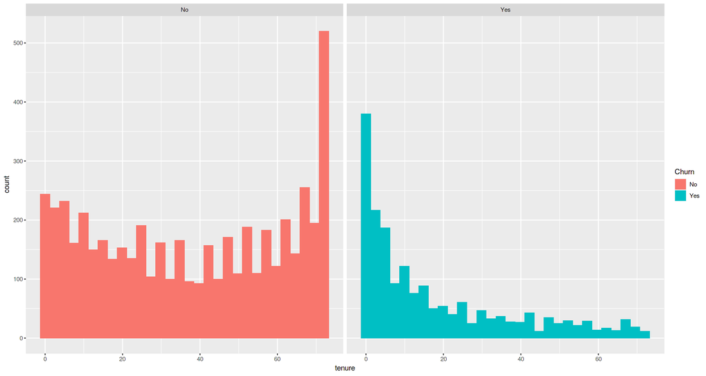

```r
options(repr.plot.width = 15, repr.plot.height = 8)

ggplot(mydata , aes( x = tenure , fill = Churn)) + geom_histogram(bins = 30) + theme(plot.title = element_text(hjust = 0.5))+ facet_wrap(. ~Churn )
```

The distibution of the churned customer is clearly positively skewed which means that more customers has low tenure period and vice versa on not churned customer although there is a spike at low tenure period also which indicat another factors inetacting with the period a cutomer stays which makes sense

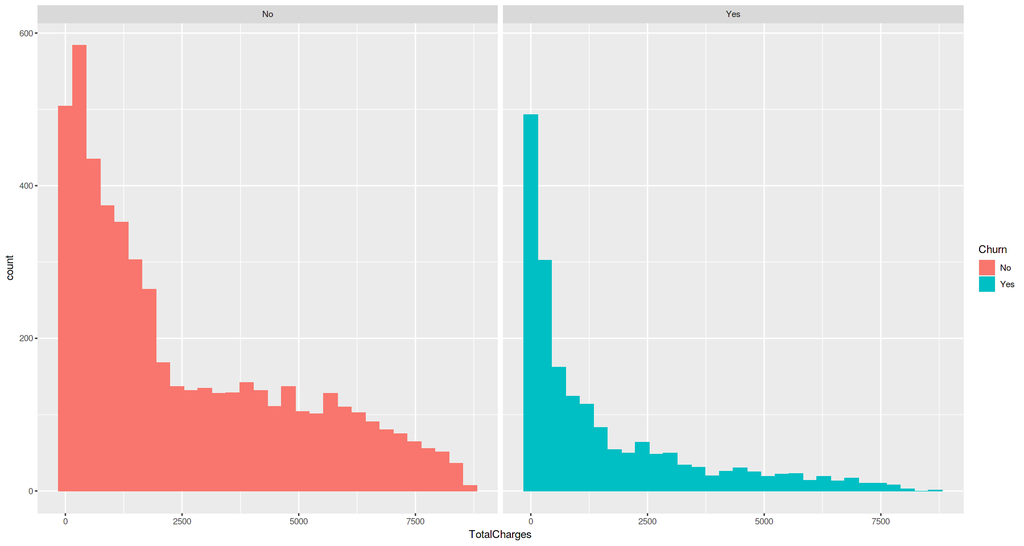

```r
ggplot(mydata , aes( x = TotalCharges , fill = Churn)) + geom_histogram(bins = 30) + theme(plot.title = element_text(hjust = 0.5)) + facet_wrap(. ~ Churn)
```

Same distribution which means this column may not be very important for the model

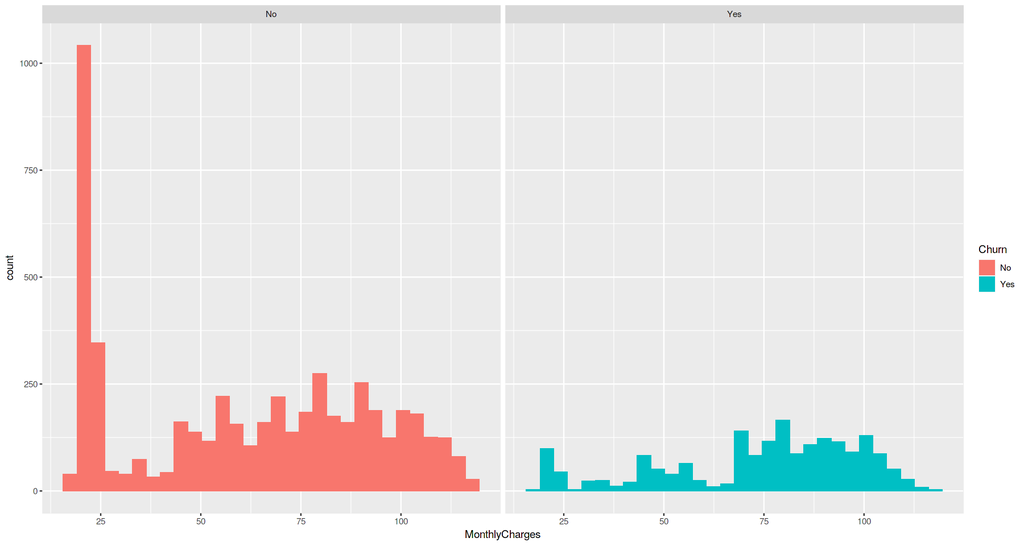

```r
ggplot(mydata , aes( x = MonthlyCharges , fill = Churn)) + geom_histogram(bins = 30) + theme(plot.title = element_text(hjust = 0.5)) + facet_wrap(. ~ Churn)
```

same as TotalCharge

# 2.2) Base Model and Model Selection

I will remove the customerID and convert the columns to be numerical, i will start with a simple label encoding to get a quick base model

```r
mydata2 =subset(mydata , select = -c(customerID)) # keep a refrence to original data
```

```r
binary_cols = c('Partner','Dependents','PhoneService','PaperlessBilling','Churn')
for(col in binary_cols) # for each column go and convert it to 1 if Yes and zero if No
    {
    mydata2[,col] = as.integer(mydata2[,col] == 'Yes')

    }
```

```r
mydata2 = mydata2 %>% mutate_if(is.character,as.factor)  %>% mutate_if(is.factor, as.numeric)
str(mydata2) # check if the data is numerical now
```

```
tibble [7,043 × 20] (S3: tbl_df/tbl/data.frame)
 $ gender          : num [1:7043] 1 2 2 2 1 1 2 1 1 2 ...
 $ SeniorCitizen   : num [1:7043] 0 0 0 0 0 0 0 0 0 0 ...
 $ Partner         : int [1:7043] 1 0 0 0 0 0 0 0 1 0 ...
 $ Dependents      : int [1:7043] 0 0 0 0 0 0 1 0 0 1 ...
 $ tenure          : num [1:7043] 1 34 2 45 2 8 22 10 28 62 ...
 $ PhoneService    : int [1:7043] 0 1 1 0 1 1 1 0 1 1 ...
 $ MultipleLines   : num [1:7043] 2 1 1 2 1 3 3 2 3 1 ...
 $ InternetService : num [1:7043] 1 1 1 1 2 2 2 1 2 1 ...
 $ OnlineSecurity  : num [1:7043] 1 3 3 3 1 1 1 3 1 3 ...
 $ OnlineBackup    : num [1:7043] 3 1 3 1 1 1 3 1 1 3 ...
 $ DeviceProtection: num [1:7043] 1 3 1 3 1 3 1 1 3 1 ...
 $ TechSupport     : num [1:7043] 1 1 1 3 1 1 1 1 3 1 ...
 $ StreamingTV     : num [1:7043] 1 1 1 1 1 3 3 1 3 1 ...
 $ StreamingMovies : num [1:7043] 1 1 1 1 1 3 1 1 3 1 ...
 $ Contract        : num [1:7043] 1 2 1 2 1 1 1 1 1 2 ...
 $ PaperlessBilling: int [1:7043] 1 0 1 0 1 1 1 0 1 0 ...
 $ PaymentMethod   : num [1:7043] 3 4 4 1 3 3 2 4 3 1 ...
 $ MonthlyCharges  : num [1:7043] 29.9 57 53.9 42.3 70.7 ...
 $ TotalCharges    : num [1:7043] 29.9 1889.5 108.2 1840.8 151.7 ...
 $ Churn           : int [1:7043] 0 0 1 0 1 1 0 0 1 0 ...
```

```r
# split the data into train, validation and test set
mydata2 = as.data.frame(mydata2)
set.seed(2)
train_index <- createDataPartition(mydata2$Churn, p = 0.7 , list = FALSE) # Taking 30% to make a validation and test set
train = mydata2[train_index,]
val_test = mydata2[-train_index,]
#making the train test data
set.seed(3)
val_index <- createDataPartition(val_test$Churn, p =0.5 , list = FALSE) # Taking 15% to make a validation and 15% and test set
val = val_test[val_index,]
test = val_test[-val_index,]

nrow(train)
nrow(val)
nrow(test)
```

4931

1056

1056

### Chossing the accuracy :

In our problem the `False negative` will very very costly as it means my model predicts this customer will not churn but actually he/she will churn which means loosing a customer and also the `False positive` means the model predicts the cutomer will churn hence efforts and money will be exerted to keep him while he/she already will saty so, i want the minimum false negative and the the minimum fals negative

```r
# logistic regression
set.seed(123)
glm <- glm(Churn ~ ., data = train, family = "binomial")
prob_preds <- predict(glm, newdata = val , type = 'response') # predict and convert predictions into positive only
# making 0.5 as a threshold
preds <- if_else(prob_preds < 0.5, 0, 1)

# evaluating the model
confusion_table <- table(preds, val$Churn)
confusionMatrix = confusionMatrix( as.factor(preds) , as.factor(val$Churn),positive = "1" )

confusion_table
confusionMatrix
```

```
preds   0   1
    0 697 114
    1  86 159
```

```
Confusion Matrix and Statistics

          Reference
Prediction   0   1
         0 697 114
         1  86 159

               Accuracy : 0.8106
                 95% CI : (0.7856, 0.8338)
    No Information Rate : 0.7415
    P-Value [Acc > NIR] : 7.168e-08

                  Kappa : 0.4889

 Mcnemar's Test P-Value : 0.05624

            Sensitivity : 0.5824
            Specificity : 0.8902
         Pos Pred Value : 0.6490
         Neg Pred Value : 0.8594
             Prevalence : 0.2585
         Detection Rate : 0.1506
   Detection Prevalence : 0.2320
      Balanced Accuracy : 0.7363

       'Positive' Class : 1
```

we can see that the 0 class has been predicted very well with Specificity = `0.8902` and Neg Pred Value = `0.8594` which means the model captured about `89%` of the people who will not churn and when it predicts 0 then `85%` of the time the actual class will be zero. but on the other side it predicted the 1 class poorly with Sensitivity = `0.5824` and Pos Pred Value = `0.6490` which means the model captured only `58%` of the churned customers and the rest predicted they will stay and even when it predicts 1 only `65%` of the times will be 1 and this mabye becasue of the class inbalance so we need to enhance the the senstivity and Pos Pred Value of the model

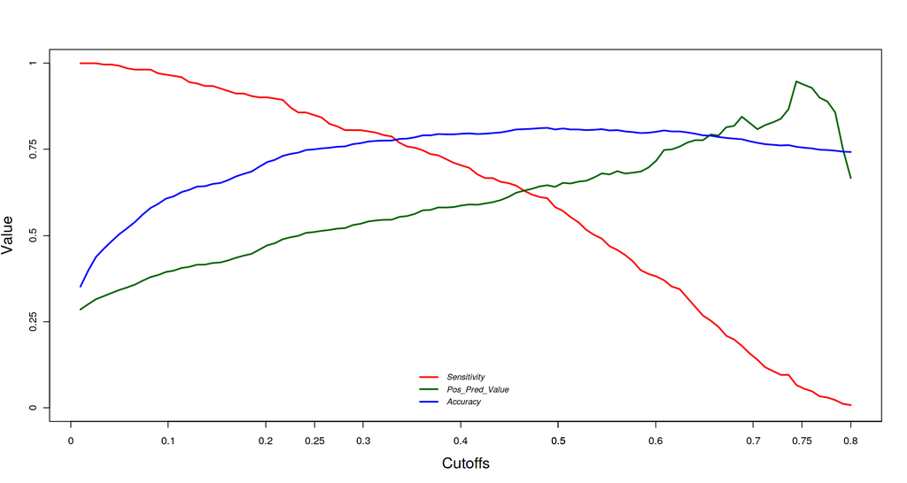

```r
# trying multiple cutoffs for determining the class to find the threshold that maximize the sensitivity and pos pred value
# this function take a cutoff and return the accuracy, senstivity and pos_pred_value on a matrix shape and based on the results of this cutoff
cal_performance <- function(cutoff)
{
  preds <- if_else(prob_preds < cutoff, 0, 1)
  conf <- confusionMatrix(as.factor(preds), as.factor(val$Churn), positive = "1")
  sensitivity <- conf$byClass[1]
  pos_pred_value <- conf$byClass[3]
  accuray <- conf$overall[1]

  out <- t(as.matrix(c(sensitivity, pos_pred_value, accuray)))
  colnames(out) <- c("sensitivity", "pos_pred_value", "accuracy")
  return(out)
}

cutoffs = seq(0.01,0.80,length=100) # trying 100 different cutoff within the range of 0.01 and 0.8
results = matrix(0,100,3) # initializing a matrix with 100 row and 3 columns one row for each cutoff results

for(i in 1:100)
{
  results[i,] = cal_performance(cutoffs[i]) # putting the results of each cutoff in a single row in the matrix
}

# plot the result to determine the best cutoff
options(repr.plot.width =15, repr.plot.height =8)
plot(cutoffs, results[,1],xlab="Cutoffs",ylab="Value",cex.lab=1.5,cex.axis=1.5,ylim=c(0,1),
     type="l",lwd=2,axes=FALSE,col=2)
axis(1,seq(0,1,length=5),seq(0,1,length=5),cex.lab=1.5)
axis(2,seq(0,1,length=5),seq(0,1,length=5),cex.lab=1.5)
lines(cutoffs,results[,2],col="darkgreen",lwd=2)
lines(cutoffs,results[,3],col=4,lwd=2)
box()
legend("bottom",col=c(2,"darkgreen",4,"darkred"),text.font =3,inset = 0.02,
       box.lty=0,cex = 0.8,
       lwd=c(2,2,2,2),c("Sensitivity","Pos_Pred_Value","Accuracy"))
axis(1, at = seq(0.1, 1, by = 0.1))
```

there is a clear tradeoff here between the overall accuracy of the model, pos_pred_value and between the senstivity so regarding our problem i don't want any customer to churn without knowing so i will try 0.3 as a cutoff to max the senstivity

```r
# logistic regression
set.seed(123)
glm <- glm(Churn ~ ., data = train, family = "binomial")
prob_preds <- predict(glm, newdata = val , type = 'response') # predict and convert predictions into positive only
# making 0.5 as a threshold
preds <- if_else(prob_preds < 0.3, 0, 1)

# evaluating the model
confusion_table <- table(preds, val$Churn)
confusionMatrix = confusionMatrix( as.factor(preds) , as.factor(val$Churn),positive = "1" )

confusion_table
confusionMatrix
```

```
preds   0   1
    0 593  54
    1 190 219
```

```
Confusion Matrix and Statistics

          Reference
Prediction   0   1
         0 593  54
         1 190 219

               Accuracy : 0.7689
                 95% CI : (0.7423, 0.7941)
    No Information Rate : 0.7415
    P-Value [Acc > NIR] : 0.02162

                  Kappa : 0.4814

 Mcnemar's Test P-Value : < 2e-16

            Sensitivity : 0.8022
            Specificity : 0.7573
         Pos Pred Value : 0.5355
         Neg Pred Value : 0.9165
             Prevalence : 0.2585
         Detection Rate : 0.2074
   Detection Prevalence : 0.3873
      Balanced Accuracy : 0.7798

       'Positive' Class : 1
```

so now our model captured about `80%` of the churned customers with losing about `4%` of thr overall accuracy and about `14%` specificity but there is no problem in that as we care more to the churned customers

```r
# Decision tree
#train and predict
set.seed(123)
Dtree = rpart(Churn ~., data = train, method = "class")  # method = class to make it binary classification
preds <- predict(Dtree,type = "class", newdata = val)

#evaluating the model

confusion_table <- table(preds, val$Churn)
confusionMatrix = confusionMatrix( as.factor(preds) , as.factor(val$Churn),positive = "1" )

confusion_table
confusionMatrix
```

```
preds   0   1
    0 713 158
    1  70 115
```

```
Confusion Matrix and Statistics

          Reference
Prediction   0   1
         0 713 158
         1  70 115

               Accuracy : 0.7841
                 95% CI : (0.758, 0.8086)
    No Information Rate : 0.7415
    P-Value [Acc > NIR] : 0.0007304

                  Kappa : 0.3708

 Mcnemar's Test P-Value : 8.326e-09

            Sensitivity : 0.4212
            Specificity : 0.9106
         Pos Pred Value : 0.6216
         Neg Pred Value : 0.8186
             Prevalence : 0.2585
         Detection Rate : 0.1089
   Detection Prevalence : 0.1752
      Balanced Accuracy : 0.6659

       'Positive' Class : 1
```

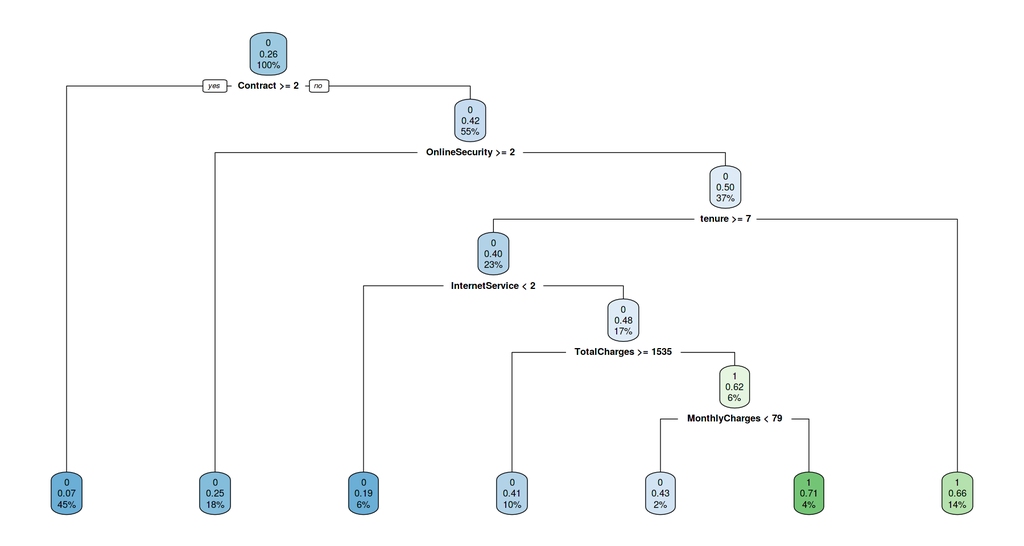

```r
options(repr.plot.width = 15, repr.plot.height = 8)
rpart.plot(Dtree)
```

i noticed here that the model didn't use a lot of the features so this is an indicator that feature engineering is important in the problem

```r
# Decision tree
#train and predict
set.seed(123)
Dtree = rpart(Churn ~., data = train, method = "class")  # method = class to make it binary classification
prob_preds <- predict(Dtree,type = "prob", newdata = val)
head(prob_preds[,2]) # these are the probabilities of class one
```

**1**

0.661786237188873

**6**

0.710659898477157

**11**

0.251700680272109

**12**

0.0728003573023671

**16**

0.0728003573023671

**18**

0.0728003573023671

```r
cal_performance <- function(cutoff)
{
  preds = ifelse(prob_preds[,2] >= cutoff , 1 , 0) # if the probability if class one is greater than 0.3 then make the class 1 other wise make it o
  conf <- confusionMatrix(as.factor(preds), as.factor(val$Churn), positive = "1")
  sensitivity <- conf$byClass[1]
  pos_pred_value <- conf$byClass[3]
  accuray <- conf$overall[1]

  out <- t(as.matrix(c(sensitivity, pos_pred_value, accuray)))
  colnames(out) <- c("sensitivity", "pos_pred_value", "accuracy")
  return(out)
}


for(i in 1:100)
{
  results[i,] = cal_performance(cutoffs[i]) # putting the results of each cutoff in a single row in the matrix
}
```

[output not shown]

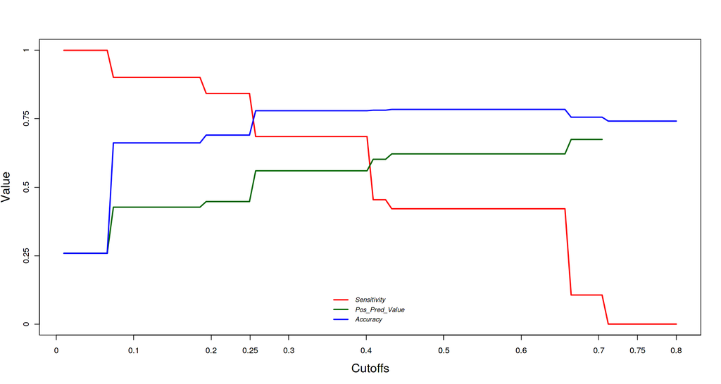

```r
# plot the result to determine the best cutoff
options(repr.plot.width =15, repr.plot.height =8)
plot(cutoffs, results[,1],xlab="Cutoffs",ylab="Value",cex.lab=1.5,cex.axis=1.5,ylim=c(0,1),
     type="l",lwd=2,axes=FALSE,col=2)
axis(1,seq(0,1,length=5),seq(0,1,length=5),cex.lab=1.5)
axis(2,seq(0,1,length=5),seq(0,1,length=5),cex.lab=1.5)
lines(cutoffs,results[,2],col="darkgreen",lwd=2)
lines(cutoffs,results[,3],col=4,lwd=2)
box()
legend("bottom",col=c(2,"darkgreen",4,"darkred"),text.font =3,inset = 0.02,
       box.lty=0,cex = 0.8,
       lwd=c(2,2,2,2),c("Sensitivity","Pos_Pred_Value","Accuracy"))
axis(1, at = seq(0.1, 1, by = 0.1))
```

the cutoff of 0.25 is good

```r
# Decision tree
#train and predict
Dtree = rpart(Churn ~., data = train, method = "class")  # method = class to make it binary classification
prob_preds <- predict(Dtree,type = "prob", newdata = val)
DT_preds = ifelse(prob_preds[,2] > 0.25 , 1 , 0) # if the probability if class one is greater than 0.3 then make the class 1 other wise make it o
#evaluating the model
confusion_table <- table(DT_preds, val$Churn)
confusionMatrix = confusionMatrix( as.factor(DT_preds) , as.factor(val$Churn),positive = "1" )

confusion_table
confusionMatrix
```

```
DT_preds   0   1
       0 499  43
       1 284 230
```

```
Confusion Matrix and Statistics

          Reference
Prediction   0   1
         0 499  43
         1 284 230

               Accuracy : 0.6903
                 95% CI : (0.6615, 0.7181)
    No Information Rate : 0.7415
    P-Value [Acc > NIR] : 0.9999

                  Kappa : 0.3726

 Mcnemar's Test P-Value : <2e-16

            Sensitivity : 0.8425
            Specificity : 0.6373
         Pos Pred Value : 0.4475
         Neg Pred Value : 0.9207
             Prevalence : 0.2585
         Detection Rate : 0.2178
   Detection Prevalence : 0.4867
      Balanced Accuracy : 0.7399

       'Positive' Class : 1
```

with this cutoff we got very good senstivity but bad overall accuracy and by the end we don't want a model that always tells us the customer will churn right ! so till now we will stick with the glm with a cutoff = 0.3

```r
# Random forest
set.seed(123)

#train and predict
RF <- randomForest(as.factor(Churn) ~ ., data=train, importance = TRUE, ntree=500, do.trace=FALSE )
preds <- predict(RF, newdata=val)
#evaluating the model
confusion_table <- table(preds, val$Churn)
confusionMatrix = confusionMatrix( as.factor(preds) , as.factor(val$Churn),positive = "1" )

confusion_table
confusionMatrix
```

```
preds   0   1
    0 710 142
    1  73 131
```

```
Confusion Matrix and Statistics

          Reference
Prediction   0   1
         0 710 142
         1  73 131

               Accuracy : 0.7964
                 95% CI : (0.7708, 0.8203)
    No Information Rate : 0.7415
    P-Value [Acc > NIR] : 1.740e-05

                  Kappa : 0.4213

 Mcnemar's Test P-Value : 3.525e-06

            Sensitivity : 0.4799
            Specificity : 0.9068
         Pos Pred Value : 0.6422
         Neg Pred Value : 0.8333
             Prevalence : 0.2585
         Detection Rate : 0.1241
   Detection Prevalence : 0.1932
      Balanced Accuracy : 0.6933

       'Positive' Class : 1
```

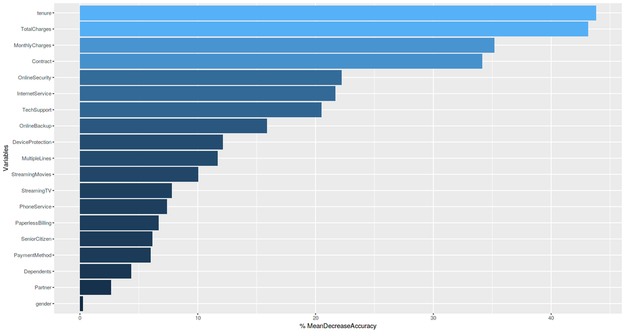

```r
# plot the importance
RF <- randomForest(as.factor(Churn) ~ ., data=train, importance = TRUE, ntree=500, do.trace=FALSE )
imp_RF <- importance(RF)
imp_DF <- data.frame(Variables = row.names(imp_RF), MeanDecreaseAccuracy = imp_RF[,3])
imp_DF <- imp_DF[order(imp_DF$MeanDecreaseAccuracy, decreasing = TRUE),]

ggplot(imp_DF, aes(x=reorder(Variables, MeanDecreaseAccuracy), y=MeanDecreaseAccuracy, fill=MeanDecreaseAccuracy)) + geom_bar(stat = 'identity') + labs(x = 'Variables', y= '% MeanDecreaseAccuracy') + coord_flip() + theme(legend.position="none")
```

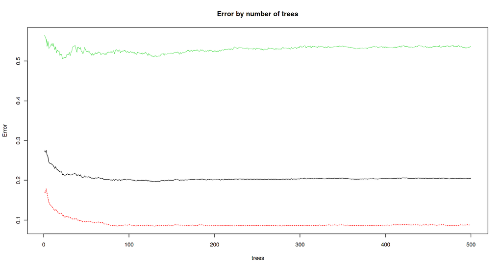

```r
plot(RF , main = "Error by number of trees")
```

We don't need more than 100 trees at most

```r
# Random forest
set.seed(123)

#train and predict
RF <- randomForest(as.factor(Churn) ~ ., data=train, importance = TRUE, ntree=100, do.trace=FALSE )
prob_preds <- predict(RF, newdata=val , type = 'prob')
head(prob_preds)
```

A matrix: 6 × 2 of type dbl

|  | 0 | 1 |
| --- | --- | --- |
| 1 | 0.35 | 0.65 |
| 6 | 0.08 | 0.92 |
| 11 | 0.87 | 0.13 |
| 12 | 0.94 | 0.06 |
| 16 | 0.92 | 0.08 |
| 18 | 0.89 | 0.11 |

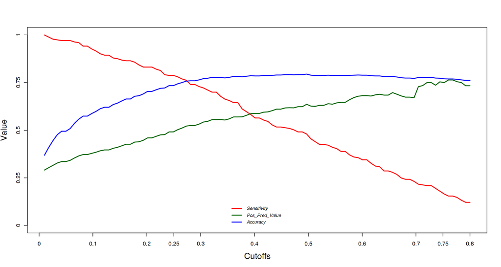

```r
cal_performance <- function(cutoff)
{
  preds = ifelse(prob_preds[,2] >= cutoff , 1 , 0) # if the probability if class one is greater than 0.3 then make the class 1 other wise make it o
  conf <- confusionMatrix(as.factor(preds), as.factor(val$Churn), positive = "1")
  sensitivity <- conf$byClass[1]
  pos_pred_value <- conf$byClass[3]
  accuray <- conf$overall[1]

  out <- t(as.matrix(c(sensitivity, pos_pred_value, accuray)))
  colnames(out) <- c("sensitivity", "pos_pred_value", "accuracy")
  return(out)
}


for(i in 1:100)
{
  results[i,] = cal_performance(cutoffs[i]) # putting the results of each cutoff in a single row in the matrix
}


# plot the result to determine the best cutoff
options(repr.plot.width =15, repr.plot.height =8)
plot(cutoffs, results[,1],xlab="Cutoffs",ylab="Value",cex.lab=1.5,cex.axis=1.5,ylim=c(0,1),
     type="l",lwd=2,axes=FALSE,col=2)
axis(1,seq(0,1,length=5),seq(0,1,length=5),cex.lab=1.5)
axis(2,seq(0,1,length=5),seq(0,1,length=5),cex.lab=1.5)
lines(cutoffs,results[,2],col="darkgreen",lwd=2)
lines(cutoffs,results[,3],col=4,lwd=2)
box()
legend("bottom",col=c(2,"darkgreen",4,"darkred"),text.font =3,inset = 0.02,
       box.lty=0,cex = 0.8,
       lwd=c(2,2,2,2),c("Sensitivity","Pos_Pred_Value","Accuracy"))
axis(1, at = seq(0.1, 1, by = 0.1))
```

0.3 is the intersection point of the accuracy and senstivity

```r
# Random forest
set.seed(123)

#train and predict
RF <- randomForest(as.factor(Churn) ~ ., data=train, importance = TRUE, ntree=100, do.trace=FALSE )
prob_preds <- predict(RF, newdata=val , type = 'prob')
RF_preds = ifelse(prob_preds[,2] >= 0.3 , 1 , 0)
#evaluating the model
confusion_table <- table(preds, val$Churn)
confusionMatrix = confusionMatrix( as.factor(RF_preds) , as.factor(val$Churn),positive = "1" )

confusion_table
confusionMatrix
```

```
preds   0   1
    0 710 142
    1  73 131
```

```
Confusion Matrix and Statistics

          Reference
Prediction   0   1
         0 608  74
         1 175 199

               Accuracy : 0.7642
                 95% CI : (0.7374, 0.7895)
    No Information Rate : 0.7415
    P-Value [Acc > NIR] : 0.04825

                  Kappa : 0.4511

 Mcnemar's Test P-Value : 2.339e-10

            Sensitivity : 0.7289
            Specificity : 0.7765
         Pos Pred Value : 0.5321
         Neg Pred Value : 0.8915
             Prevalence : 0.2585
         Detection Rate : 0.1884
   Detection Prevalence : 0.3542
      Balanced Accuracy : 0.7527

       'Positive' Class : 1
```

The gml model show better overall accuracy and better senstivity so i will continue with it. Let's evaluate it on the full test set

```r
# logistic regression
set.seed(123)
train_full = rbind(train,val) # concating the train and validation to train on both of them
glm <- glm(Churn ~ ., data = train_full, family = "binomial")
prob_preds <- predict(glm, newdata = test , type = 'response') # predict and convert predictions into positive only
# making 0.5 as a threshold
glm_preds <- if_else(prob_preds < 0.3, 0, 1)

# evaluating the model
confusion_table <- table(glm_preds, test$Churn)
confusionMatrix = confusionMatrix( as.factor(glm_preds) , as.factor(test$Churn),positive = "1" )

confusion_table
confusionMatrix
```

```
glm_preds   0   1
        0 571  58
        1 179 248
```

```
Confusion Matrix and Statistics

          Reference
Prediction   0   1
         0 571  58
         1 179 248

               Accuracy : 0.7756
                 95% CI : (0.7492, 0.8004)
    No Information Rate : 0.7102
    P-Value [Acc > NIR] : 9.715e-07

                  Kappa : 0.5119

 Mcnemar's Test P-Value : 6.449e-15

            Sensitivity : 0.8105
            Specificity : 0.7613
         Pos Pred Value : 0.5808
         Neg Pred Value : 0.9078
             Prevalence : 0.2898
         Detection Rate : 0.2348
   Detection Prevalence : 0.4044
      Balanced Accuracy : 0.7859

       'Positive' Class : 1
```

## the final results for the base model is :

Accuracy : 0.7756

Sensitivity : 0.8105

Specificity : 0.7613

Pos Pred Value : 0.5808

Neg Pred Value : 0.9078

i will try to enhance it through feature engineering

# 2.3) Feature Engineering

I want to see the impact of one hot encoding

```r
mydata3 <- read_csv("../input/telco-customer-churn/WA_Fn-UseC_-Telco-Customer-Churn.csv") #Reading the Data
attr(mydata3, 'spec') <- NULL # just to remove a warning about specifications
mydata3$customerID <- NULL # remove customer id
mydata3[rowSums(is.na(mydata3)) > 0,'TotalCharges'] = mydata3[rowSums(is.na(mydata3)) > 0,'MonthlyCharges']
```

```r
mydata3[rowSums(is.na(mydata3)) > 0,'TotalCharges'] = mydata3[rowSums(is.na(mydata3)) > 0,'MonthlyCharges']
Churn = ifelse(mydata3$Churn == 'Yes' , 1 , 0)
mydata3$Churn <- NULL # remove Churn

#making the one hot encoding
dmy <- dummyVars(" ~ .", data = mydata3)
mydata3_dmy_encoded  <- data.frame(predict(dmy, newdata = mydata))
mydata3_dmy_encoded = cbind(mydata3_dmy_encoded,Churn)
head(mydata3_dmy_encoded)
```

A data.frame: 6 × 46

|  | genderFemale <dbl> | genderMale <dbl> | SeniorCitizen <dbl> | PartnerNo <dbl> | PartnerYes <dbl> | DependentsNo <dbl> | DependentsYes <dbl> | tenure <dbl> | PhoneServiceNo <dbl> | PhoneServiceYes <dbl> | ⋯ | ContractTwo.year <dbl> | PaperlessBillingNo <dbl> | PaperlessBillingYes <dbl> | PaymentMethodBank.transfer..automatic. <dbl> | PaymentMethodCredit.card..automatic. <dbl> | PaymentMethodElectronic.check <dbl> | PaymentMethodMailed.check <dbl> | MonthlyCharges <dbl> | TotalCharges <dbl> | Churn <dbl> |
| --- | --- | --- | --- | --- | --- | --- | --- | --- | --- | --- | --- | --- | --- | --- | --- | --- | --- | --- | --- | --- | --- |
| 1 | 1 | 0 | 0 | 0 | 1 | 1 | 0 | 1 | 1 | 0 | ⋯ | 0 | 0 | 1 | 0 | 0 | 1 | 0 | 29.85 | 29.85 | 0 |
| 2 | 0 | 1 | 0 | 1 | 0 | 1 | 0 | 34 | 0 | 1 | ⋯ | 0 | 1 | 0 | 0 | 0 | 0 | 1 | 56.95 | 1889.50 | 0 |
| 3 | 0 | 1 | 0 | 1 | 0 | 1 | 0 | 2 | 0 | 1 | ⋯ | 0 | 0 | 1 | 0 | 0 | 0 | 1 | 53.85 | 108.15 | 1 |
| 4 | 0 | 1 | 0 | 1 | 0 | 1 | 0 | 45 | 1 | 0 | ⋯ | 0 | 1 | 0 | 1 | 0 | 0 | 0 | 42.30 | 1840.75 | 0 |
| 5 | 1 | 0 | 0 | 1 | 0 | 1 | 0 | 2 | 0 | 1 | ⋯ | 0 | 0 | 1 | 0 | 0 | 1 | 0 | 70.70 | 151.65 | 1 |
| 6 | 1 | 0 | 0 | 1 | 0 | 1 | 0 | 8 | 0 | 1 | ⋯ | 0 | 0 | 1 | 0 | 0 | 1 | 0 | 99.65 | 820.50 | 1 |

```r
# split the data into train, validation and test set
mydata3_dmy_encoded = as.data.frame(mydata3_dmy_encoded)
set.seed(4)
train_index <- createDataPartition(mydata3_dmy_encoded$Churn, p = 0.7 , list = FALSE ) # Taking 30% to make a validation and test set
train = mydata3_dmy_encoded[train_index,]
val_test = mydata3_dmy_encoded[-train_index,]
#making the train test data
set.seed(5)
val_index <- createDataPartition(val_test$Churn, p =0.5 , list = FALSE) # Taking 15% to make a validation and 15% and test set
val = val_test[val_index,]
test = val_test[-val_index,]

# logistic regression
set.seed(123)
glm <- glm(Churn ~ ., data = train, family = "binomial")
prob_preds <- predict(glm, newdata = val , type = 'response') # predict and convert predictions into positive only
# making 0.3 as a threshold
preds <- if_else(prob_preds < 0.3, 0, 1)

# evaluating the model
confusion_table <- table(preds, val$Churn)
confusionMatrix = confusionMatrix( as.factor(preds) , as.factor(val$Churn),positive = "1" )

confusion_table
confusionMatrix
```

```
preds   0   1
    0 608  67
    1 175 206
```

```
Confusion Matrix and Statistics

          Reference
Prediction   0   1
         0 608  67
         1 175 206

               Accuracy : 0.7708
                 95% CI : (0.7443, 0.7959)
    No Information Rate : 0.7415
    P-Value [Acc > NIR] : 0.01518

                  Kappa : 0.4705

 Mcnemar's Test P-Value : 6.06e-12

            Sensitivity : 0.7546
            Specificity : 0.7765
         Pos Pred Value : 0.5407
         Neg Pred Value : 0.9007
             Prevalence : 0.2585
         Detection Rate : 0.1951
   Detection Prevalence : 0.3608
      Balanced Accuracy : 0.7655

       'Positive' Class : 1
```

we can see that the model become worst than the label encoding so we will stick to it but first let's try the interaction variables

```r
mydata4 <- read_csv("../input/telco-customer-churn/WA_Fn-UseC_-Telco-Customer-Churn.csv") #Reading the Data
attr(mydata4, 'spec') <- NULL # just to remove a warning about specifications
mydata4$customerID <- NULL # remove customer id
mydata4[rowSums(is.na(mydata4)) > 0,'TotalCharges'] = mydata4[rowSums(is.na(mydata4)) > 0,'MonthlyCharges']
mydata4 = as.data.frame(mydata4)

binary_cols = c('Partner','Dependents','PhoneService','PaperlessBilling','Churn')
for(col in binary_cols) # for each column go and convert it to 1 if Yes and zero if No
    {
    mydata4[,col] = as.integer(mydata4[,col] == 'Yes')

    }

mydata4 = mydata4 %>% mutate_if(is.character,as.factor)  %>% mutate_if(is.factor, as.numeric)

head(mydata4)
```

A data.frame: 6 × 20

|  | gender <dbl> | SeniorCitizen <dbl> | Partner <int> | Dependents <int> | tenure <dbl> | PhoneService <int> | MultipleLines <dbl> | InternetService <dbl> | OnlineSecurity <dbl> | OnlineBackup <dbl> | DeviceProtection <dbl> | TechSupport <dbl> | StreamingTV <dbl> | StreamingMovies <dbl> | Contract <dbl> | PaperlessBilling <int> | PaymentMethod <dbl> | MonthlyCharges <dbl> | TotalCharges <dbl> | Churn <int> |
| --- | --- | --- | --- | --- | --- | --- | --- | --- | --- | --- | --- | --- | --- | --- | --- | --- | --- | --- | --- | --- |
| 1 | 1 | 0 | 1 | 0 | 1 | 0 | 2 | 1 | 1 | 3 | 1 | 1 | 1 | 1 | 1 | 1 | 3 | 29.85 | 29.85 | 0 |
| 2 | 2 | 0 | 0 | 0 | 34 | 1 | 1 | 1 | 3 | 1 | 3 | 1 | 1 | 1 | 2 | 0 | 4 | 56.95 | 1889.50 | 0 |
| 3 | 2 | 0 | 0 | 0 | 2 | 1 | 1 | 1 | 3 | 3 | 1 | 1 | 1 | 1 | 1 | 1 | 4 | 53.85 | 108.15 | 1 |
| 4 | 2 | 0 | 0 | 0 | 45 | 0 | 2 | 1 | 3 | 1 | 3 | 3 | 1 | 1 | 2 | 0 | 1 | 42.30 | 1840.75 | 0 |
| 5 | 1 | 0 | 0 | 0 | 2 | 1 | 1 | 2 | 1 | 1 | 1 | 1 | 1 | 1 | 1 | 1 | 3 | 70.70 | 151.65 | 1 |
| 6 | 1 | 0 | 0 | 0 | 8 | 1 | 3 | 2 | 1 | 1 | 3 | 1 | 3 | 3 | 1 | 1 | 3 | 99.65 | 820.50 | 1 |

```r
# i'm just using mydata5 to get the categorical variables and make the interactions with it then append them in mydata4
mydata5 <- read_csv("../input/telco-customer-churn/WA_Fn-UseC_-Telco-Customer-Churn.csv") #Reading the Data
attr(mydata5, 'spec') <- NULL # just to remove a warning about specifications
mydata5$customerID <- NULL # remove customer id
mydata5$Churn <- NULL # removing Churn as we don't want it in the interactions
mydata5 = as.data.frame(mydata5)
```

```r
cat_names <- colnames(mydata5[,sapply(mydata5,class) == 'character']) # get all the categorical names

interaction_names = c() # this will be the list with the interactions names
for (i in 2: length(cat_names) - 1 )
    {

    for(j in (i+1): length(cat_names) )
        {

          interaction_name = paste(cat_names[i],cat_names[j],sep = '_') # the interaction name will be the 2 columns name seperated with -
          interaction = paste(mydata5[,cat_names[i]] , mydata5[,cat_names[j]] , sep = '_') # this is the interaction column values i will access the 2 columns with their names and paste their values with - sperator
          mydata4[,interaction_name] = interaction # i'm appending in mydata3 which is my the converted as in the base model dataframe
          interaction_names = c(interaction_names,interaction_name)     # append the names in a list
        }

    }
```

```r
interaction_names # these are the columns names,  it's an interaction between each column with all other columns
```

1. 'gender_Partner'

2. 'gender_Dependents'

3. 'gender_PhoneService'

4. 'gender_MultipleLines'

5. 'gender_InternetService'

6. 'gender_OnlineSecurity'

7. 'gender_OnlineBackup'

8. 'gender_DeviceProtection'

9. 'gender_TechSupport'

10. 'gender_StreamingTV'

11. 'gender_StreamingMovies'

12. 'gender_Contract'

13. 'gender_PaperlessBilling'

14. 'gender_PaymentMethod'

15. 'Partner_Dependents'

16. 'Partner_PhoneService'

17. 'Partner_MultipleLines'

18. 'Partner_InternetService'

19. 'Partner_OnlineSecurity'

20. 'Partner_OnlineBackup'

21. 'Partner_DeviceProtection'

22. 'Partner_TechSupport'

23. 'Partner_StreamingTV'

24. 'Partner_StreamingMovies'

25. 'Partner_Contract'

26. 'Partner_PaperlessBilling'

27. 'Partner_PaymentMethod'

28. 'Dependents_PhoneService'

29. 'Dependents_MultipleLines'

30. 'Dependents_InternetService'

31. 'Dependents_OnlineSecurity'

32. 'Dependents_OnlineBackup'

33. 'Dependents_DeviceProtection'

34. 'Dependents_TechSupport'

35. 'Dependents_StreamingTV'

36. 'Dependents_StreamingMovies'

37. 'Dependents_Contract'

38. 'Dependents_PaperlessBilling'

39. 'Dependents_PaymentMethod'

40. 'PhoneService_MultipleLines'

41. 'PhoneService_InternetService'

42. 'PhoneService_OnlineSecurity'

43. 'PhoneService_OnlineBackup'

44. 'PhoneService_DeviceProtection'

45. 'PhoneService_TechSupport'

46. 'PhoneService_StreamingTV'

47. 'PhoneService_StreamingMovies'

48. 'PhoneService_Contract'

49. 'PhoneService_PaperlessBilling'

50. 'PhoneService_PaymentMethod'

51. 'MultipleLines_InternetService'

52. 'MultipleLines_OnlineSecurity'

53. 'MultipleLines_OnlineBackup'

54. 'MultipleLines_DeviceProtection'

55. 'MultipleLines_TechSupport'

56. 'MultipleLines_StreamingTV'

57. 'MultipleLines_StreamingMovies'

58. 'MultipleLines_Contract'

59. 'MultipleLines_PaperlessBilling'

60. 'MultipleLines_PaymentMethod'

61. 'InternetService_OnlineSecurity'

62. 'InternetService_OnlineBackup'

63. 'InternetService_DeviceProtection'

64. 'InternetService_TechSupport'

65. 'InternetService_StreamingTV'

66. 'InternetService_StreamingMovies'

67. 'InternetService_Contract'

68. 'InternetService_PaperlessBilling'

69. 'InternetService_PaymentMethod'

70. 'OnlineSecurity_OnlineBackup'

71. 'OnlineSecurity_DeviceProtection'

72. 'OnlineSecurity_TechSupport'

73. 'OnlineSecurity_StreamingTV'

74. 'OnlineSecurity_StreamingMovies'

75. 'OnlineSecurity_Contract'

76. 'OnlineSecurity_PaperlessBilling'

77. 'OnlineSecurity_PaymentMethod'

78. 'OnlineBackup_DeviceProtection'

79. 'OnlineBackup_TechSupport'

80. 'OnlineBackup_StreamingTV'

81. 'OnlineBackup_StreamingMovies'

82. 'OnlineBackup_Contract'

83. 'OnlineBackup_PaperlessBilling'

84. 'OnlineBackup_PaymentMethod'

85. 'DeviceProtection_TechSupport'

86. 'DeviceProtection_StreamingTV'

87. 'DeviceProtection_StreamingMovies'

88. 'DeviceProtection_Contract'

89. 'DeviceProtection_PaperlessBilling'

90. 'DeviceProtection_PaymentMethod'

91. 'TechSupport_StreamingTV'

92. 'TechSupport_StreamingMovies'

93. 'TechSupport_Contract'

94. 'TechSupport_PaperlessBilling'

95. 'TechSupport_PaymentMethod'

96. 'StreamingTV_StreamingMovies'

97. 'StreamingTV_Contract'

98. 'StreamingTV_PaperlessBilling'

99. 'StreamingTV_PaymentMethod'

100. 'StreamingMovies_Contract'

101. 'StreamingMovies_PaperlessBilling'

102. 'StreamingMovies_PaymentMethod'

103. 'Contract_PaperlessBilling'

104. 'Contract_PaymentMethod'

105. 'PaperlessBilling_PaymentMethod'

```r
head(mydata4) #This is the dataframe now
```

A data.frame: 6 × 125

|  | gender <dbl> | SeniorCitizen <dbl> | Partner <int> | Dependents <int> | tenure <dbl> | PhoneService <int> | MultipleLines <dbl> | InternetService <dbl> | OnlineSecurity <dbl> | OnlineBackup <dbl> | ⋯ | StreamingTV_StreamingMovies <chr> | StreamingTV_Contract <chr> | StreamingTV_PaperlessBilling <chr> | StreamingTV_PaymentMethod <chr> | StreamingMovies_Contract <chr> | StreamingMovies_PaperlessBilling <chr> | StreamingMovies_PaymentMethod <chr> | Contract_PaperlessBilling <chr> | Contract_PaymentMethod <chr> | PaperlessBilling_PaymentMethod <chr> |
| --- | --- | --- | --- | --- | --- | --- | --- | --- | --- | --- | --- | --- | --- | --- | --- | --- | --- | --- | --- | --- | --- |
| 1 | 1 | 0 | 1 | 0 | 1 | 0 | 2 | 1 | 1 | 3 | ⋯ | No_No | No_Month-to-month | No_Yes | No_Electronic check | No_Month-to-month | No_Yes | No_Electronic check | Month-to-month_Yes | Month-to-month_Electronic check | Yes_Electronic check |
| 2 | 2 | 0 | 0 | 0 | 34 | 1 | 1 | 1 | 3 | 1 | ⋯ | No_No | No_One year | No_No | No_Mailed check | No_One year | No_No | No_Mailed check | One year_No | One year_Mailed check | No_Mailed check |
| 3 | 2 | 0 | 0 | 0 | 2 | 1 | 1 | 1 | 3 | 3 | ⋯ | No_No | No_Month-to-month | No_Yes | No_Mailed check | No_Month-to-month | No_Yes | No_Mailed check | Month-to-month_Yes | Month-to-month_Mailed check | Yes_Mailed check |
| 4 | 2 | 0 | 0 | 0 | 45 | 0 | 2 | 1 | 3 | 1 | ⋯ | No_No | No_One year | No_No | No_Bank transfer (automatic) | No_One year | No_No | No_Bank transfer (automatic) | One year_No | One year_Bank transfer (automatic) | No_Bank transfer (automatic) |
| 5 | 1 | 0 | 0 | 0 | 2 | 1 | 1 | 2 | 1 | 1 | ⋯ | No_No | No_Month-to-month | No_Yes | No_Electronic check | No_Month-to-month | No_Yes | No_Electronic check | Month-to-month_Yes | Month-to-month_Electronic check | Yes_Electronic check |
| 6 | 1 | 0 | 0 | 0 | 8 | 1 | 3 | 2 | 1 | 1 | ⋯ | Yes_Yes | Yes_Month-to-month | Yes_Yes | Yes_Electronic check | Yes_Month-to-month | Yes_Yes | Yes_Electronic check | Month-to-month_Yes | Month-to-month_Electronic check | Yes_Electronic check |

```r
# converting the columns to be numerical
mydata4 = mydata4 %>% mutate_if(is.character,as.factor)  %>% mutate_if(is.factor, as.numeric)
```

```r
set.seed(4)
# split the data into train, validation and test set
train_index <- createDataPartition(mydata4$Churn, p = 0.7 , list = FALSE ) # Taking 30% to make a validation and test set
train = mydata4[train_index,]
val_test = mydata4[-train_index,]
#making the train test data
set.seed(5)
val_index <- createDataPartition(val_test$Churn, p =0.5 , list = FALSE) # Taking 15% to make a validation and 15% and test set
val = val_test[val_index,]
test = val_test[-val_index,]

# logistic regression
set.seed(123)
glm <- glm(Churn ~ ., data = train, family = "binomial")
prob_preds <- predict(glm, newdata = val , type = 'response') # predict and convert predictions into positive only
# making 0.3 as a threshold
preds <- if_else(prob_preds < 0.30, 0, 1)

# evaluating the model
confusion_table <- table(preds, val$Churn)
confusionMatrix = confusionMatrix( as.factor(preds) , as.factor(val$Churn),positive = "1" )

confusion_table
confusionMatrix
```

```
preds   0   1
    0 600  69
    1 183 204
```

```
Confusion Matrix and Statistics

          Reference
Prediction   0   1
         0 600  69
         1 183 204

               Accuracy : 0.7614
                 95% CI : (0.7345, 0.7868)
    No Information Rate : 0.7415
    P-Value [Acc > NIR] : 0.07391

                  Kappa : 0.4521

 Mcnemar's Test P-Value : 1.092e-12

            Sensitivity : 0.7473
            Specificity : 0.7663
         Pos Pred Value : 0.5271
         Neg Pred Value : 0.8969
             Prevalence : 0.2585
         Detection Rate : 0.1932
   Detection Prevalence : 0.3665
      Balanced Accuracy : 0.7568

       'Positive' Class : 1
```

it didn't work well mabye we need to do feature selection because the model is overfitting due the large number of features

# 2.4) Feature Selection

```r
# plot the importance
set.seed(12345)
RF <- randomForest(as.factor(Churn) ~ ., data=train, importance = TRUE, ntree=50, do.trace=FALSE )
imp_RF <- importance(RF)
imp_DF <- data.frame(Variables = row.names(imp_RF), MeanDecreaseAccuracy = imp_RF[,3])
imp_DF <- imp_DF[order(imp_DF$MeanDecreaseAccuracy, decreasing = TRUE),]
```

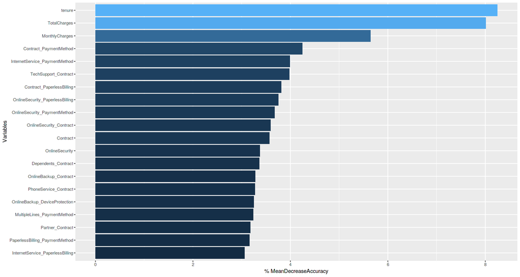

```r
# ploting the most 20 important column
ggplot(imp_DF[1:20,], aes(x=reorder(Variables, MeanDecreaseAccuracy), y=MeanDecreaseAccuracy, fill=MeanDecreaseAccuracy)) + geom_bar(stat = 'identity') + labs(x = 'Variables', y= '% MeanDecreaseAccuracy') + coord_flip() + theme(legend.position="none")
```

we can see that there are some interaction variables that replaced original columns in importance

```r
# train on the most 50 important column
mydata4_subset = mydata4[,imp_DF[1:20,]$Variables]
Churn = mydata4$Churn
mydata4_subset = cbind(mydata4_subset,Churn)
set.seed(4)
# split the data into train, validation and test set
train_index <- createDataPartition(mydata4_subset$Churn, p = 0.7 , list = FALSE ) # Taking 30% to make a validation and test set
train = mydata4_subset[train_index,]
val_test = mydata4_subset[-train_index,]
#making the train test data
set.seed(5)
val_index <- createDataPartition(val_test$Churn, p =0.5 , list = FALSE) # Taking 15% to make a validation and 15% and test set
val = val_test[val_index,]
test = val_test[-val_index,]

# logistic regression
set.seed(123)
glm <- glm(Churn ~ ., data = train, family = "binomial")
prob_preds <- predict(glm, newdata = val , type = 'response') # predict and convert predictions into positive only
# making 0.3 as a threshold
preds <- if_else(prob_preds < 0.30, 0, 1)

# evaluating the model
confusion_table <- table(preds, val$Churn)
confusionMatrix = confusionMatrix( as.factor(preds) , as.factor(val$Churn),positive = "1" )

confusion_table
confusionMatrix
```

```
preds   0   1
    0 604  64
    1 179 209
```

```
Confusion Matrix and Statistics

          Reference
Prediction   0   1
         0 604  64
         1 179 209

               Accuracy : 0.7699
                 95% CI : (0.7433, 0.795)
    No Information Rate : 0.7415
    P-Value [Acc > NIR] : 0.01816

                  Kappa : 0.4722

 Mcnemar's Test P-Value : 2.61e-13

            Sensitivity : 0.7656
            Specificity : 0.7714
         Pos Pred Value : 0.5387
         Neg Pred Value : 0.9042
             Prevalence : 0.2585
         Detection Rate : 0.1979
   Detection Prevalence : 0.3674
      Balanced Accuracy : 0.7685

       'Positive' Class : 1
```

The results didn't improved

# Stack model

## I will feed a bagging model with the 3 models predictions that i used

```r
set.seed(12345)
combinedDF <- data.frame(RF_preds ,DT_preds,glm_preds, Churn = val$Churn)
stack.fit <- train(as.factor(Churn) ~ . , method = "treebag" , data = combinedDF  )

stack.pred.validation <- predict(stack.fit , val)
confusionMatrix( as.factor(stack.pred.validation) , as.factor(val$Churn),positive = "1" )
```

```
Confusion Matrix and Statistics

          Reference
Prediction   0   1
         0 783 273
         1   0   0

               Accuracy : 0.7415
                 95% CI : (0.7139, 0.7677)
    No Information Rate : 0.7415
    P-Value [Acc > NIR] : 0.5163

                  Kappa : 0

 Mcnemar's Test P-Value : <2e-16

            Sensitivity : 0.0000
            Specificity : 1.0000
         Pos Pred Value :    NaN
         Neg Pred Value : 0.7415
             Prevalence : 0.2585
         Detection Rate : 0.0000
   Detection Prevalence : 0.0000
      Balanced Accuracy : 0.5000

       'Positive' Class : 1
```

# 3) Results

the best model is the glm from the base model with :

Accuracy : **0.7756**

Sensitivity : **0.8105**

Specificity : **0.7613**

Pos Pred Value : **0.5808**

Neg Pred Value : **0.9078**

# 4) Conclusion

So we went through very detailed analysis to the modeld evaluating and we saw the tradeoff between the senstivity, accuracy and spcificity of the model and how to relate them in our problem. The glm after trying many cutoffs showed good results that i wished they could be improved through feature selection but mabye becasue the small size of the data the model didn't catch all the patterns, but any ways the model was able to predict about `81%` of the churned customers which is good